# ML literature in PH

Exercise using unsupervised machine learning

Julian Flowers

1 February 2019

# Introduction

In this exercise we are going to look at trends in machine learning algorithms used in the public health literature.

## Objectives

1. Learn how to download PubMed abstracts to R using the `pubmedAbstractR` function in the `myScrapers` package.
2. Learn how to perform a basic natural processing pipeline using the `tidytext` and `quanteda` package
3. Use unsupervised machine learning to classify abstracts and try and extract themes and trends from abstract titles

This exercise is based on https://projects.datacamp.com/projects/158.

### First step

We need to install relevant packages if not already installed. `tidytext` and `quanteda` can be installed from CRAN. `myScrapers` is available from Github. We’ll also use `dplyr` for data wrangling and `ggplot2` for visualisation and `stm` for topics modelling.

```r
library(stm)
```

### Downloading abstracts

To this we need to pass 4 arguments to the `pubmedAbstractR` function:

- a `search` term - this can take full Pubmed syntax (it is built on top of `RISmed`)
- a `start` year
- an `end` year
- `n` = number of abstracts to be downloaded. We recommend using n = 1 initially - this will return how many abstracts are available to be downloaded and you can an adjust the value of n accordingly. The default value is 1000.

### Example search

```r
search <- "randomforest public health"
start <- 2010
end <- 2018
n <- 1

result <- pubmedAbstractR(search = search, start = start, end = end, n = n)
```

We can see this search retrieves 20 titles - we can download all for inspection

```r
n <- 20
rf <- pubmedAbstractR(search = search, start = start, end = end, n = n)
```

[output not shown]

```r
head(rf, 10)
```

| title | abstract | journal | DOI | year |
| --- | --- | --- | --- | --- |
| Searching for the Novel Specific Predictors of Prostate Cancer in Urine: The Analysis of 84 miRNA Expression. |  | International journal of molecular sciences | 30562989 | 2018 |
| Variable importance-weighted Random Forests. | Random Forests is a popular classification and regression method that has proven powerful for various prediction problems in biological studies. However, its performance often deteriorates when the nu… | Quantitative biology (Beijing, China) | 30034909 | 2018 |
| Analysis and multiclass classification of pathological knee joints using vibroarthrographic signals. | BACKGROUND AND OBJECTIVE: Vibroarthrography (VAG) is a method developed for sensitive and objective assessment of articular function. Although the VAG method is still in development, it shows high acc… | Computer methods and programs in biomedicine | 29249345 | 2017 |
| Suitability of random forest analysis for epidemiological research: Exploring sociodemographic and lifestyle-related risk factors of overweight in a cross-sectional design. | AIMS: Factors that contribute to the development of overweight are numerous and form a complex structure with many unknown interactions and associations. We aimed to explore this structure (i.e. the m… | Scandinavian journal of public health | 29082809 | 2017 |
| Prediction of delayed retention of antibodies in hydrophobic interaction chromatography from sequence using machine learning. | The hydrophobicity of a monoclonal antibody is an important biophysical property relevant for its developability into a therapeutic. In addition to characterizing heterogeneity, Hydrophobic Interactio… | Bioinformatics (Oxford, England) | 28961999 | 2017 |
| A data mining approach for identifying pathway-gene biomarkers for predicting clinical outcome: A case study of erlotinib and sorafenib. | A novel data mining procedure is proposed for identifying potential pathway-gene biomarkers from preclinical drug sensitivity data for predicting clinical responses to erlotinib or sorafenib. The anal… | PloS one | 28792525 | 2017 |
| Do causal concentration-response functions exist? A critical review of associational and causal relations between fine particulate matter and mortality. | Concentration-response (C-R) functions relating concentrations of pollutants in ambient air to mortality risks or other adverse health effects provide the basis for many public health risk assessments… | Critical reviews in toxicology | 28657395 | 2017 |
| The influence of the rs6295 gene polymorphism on serotonin-1A receptor distribution investigated with PET in patients with major depression applying machine learning. |  | Translational psychiatry | 28608854 | 2017 |
| Identification of temporal genes involved in the mechanisms of spinal cord injury. | OBJECTIVES: As a high-cost neurological disability, spinal cord injury (SCI) can result in permanent paralysis and loss of sensation. To identify the temporal genes involved in the pathogenesis of SCI… | Spinal cord | 28071686 | 2017 |
| A New Prediction Model for Evaluating Treatment-Resistant Depression. | OBJECTIVE: Despite a broad arsenal of antidepressants, about a third of patients suffering from major depressive disorder (MDD) do not respond sufficiently to adequate treatment. Using the data pool o… | The Journal of clinical psychiatry | 28068461 | 2017 |

## Your turn

Try searching for and downloading machine learning articles in public health over the last 10 years. (Hint: using public health[mh] in your search string, restricts the search to MeSH headings ). Note: it takes a few minutes to download the abstracts.

HINT: https://gist.github.com/julianflowers/2ca8a062e86b7752bacbc66609314d95

### Simple NLP pipeline

There is a fairly standard approach:

- Ingest your text
- Clean texts - remove unwanted text e.g. stopwords (common English words like *the, a, at, in* etc.), remove punctuation, remove html tags and urls
- Create a *corpus* - that is a body of texts - this is a speciliased data format which holds the raw text along with metadata - this is necessary for some package like `quanteda`.
- Tokenise - that is split texts into basic units - this can be anything from single characters to paragraphs. The usual approach is to split texts into words - this is known as a *bag of words*. A single word is known as a 1-gram; if we use two word combinations, this is *bigram*, 3 word is a 3-gram and so on. Combinations of non consecutive words are known as *skip grams*.
- Create a **document term** or **document feature matrix**. This is the basis of futher analysis, and is a table where the rows are your documets, the columns are your ngrams (terms) and the cells are counts of each term in each document. This matrix will be *sparse* - that is full of 0s, and can have large numbers of columns (sometimes billions).

We are going to do a number of things.

1. *Tokenise* the title of each article into 2 word combinations (bigrams) (because it’ll make it easier to extract algorithm names). You can achieve this with the `create_bigrams` function in `myScrapers` or you can build it from scratch (https://www.tidytextmining.com/ngrams.html), and count token frequency.

**Tokenise the titles of your downloaded abstracts and visualise your result showing the most frequent bigrams over time**

Visualise your result.

What conclusions do you draw?

## Topic modelling

Topic modelling is a form of unsupervised machine learning intended to find themes in bodies of texts.

To perform topic modelling we need to:

- Convert our data to a matrix format known as a document-term-matrix (DTM) or a sparese matrix.
- For this exercise we will use the `stm` (Structural topic modelling) package and apply 15 topics (note this is soemwhat arbitrary - see further reading for techniques to determine statistical optima for numbers of topic models).
- We’ll also use single word models rather than bigrams.

```r
big_dfm <- check %>%
  unnest_tokens(word, title) %>%
  anti_join(get_stopwords()) %>%
  count(DOI, word, sort = TRUE) %>%
  cast_dfm(DOI, word, n )
```

```r
library(stm)
library(pipeR)
devtools::install_github("timelyportfolio/stmCorrViz@htmlwidget")


textProcessor(
  documents=check$abstract
  ,metadata=check
) %>>%
  (
    prepDocuments( .$documents, .$vocab, .$meta )
  ) %>>%
( ~out ) %>>% #save as out for later
  ({
    set.seed(02138)
    stm( .$documents, .$vocab, 20,
       #prevalence=~treatment + s(year),
       data = .$meta
    )
  }) %>>%
~ mod_out

stmCorrViz::stmCorrViz(mod_out, "test.html")

proc <- textProcessor(documents = check$abstract, metadata = check)
out <- prepDocuments(proc$documents, proc$vocab, proc$meta)
docs <- out$documents
vocab <- out$vocab
meta <- out$meta

prevfit <- stm(documents = docs, vocab = vocab, K = 50, max.em.its = 50, data = meta, init.type = "Spectral")

save.image("stm_test.RData")
```

the `stm` has a number of useful plotting options to visualise your results. **Try plotting your results and createing a word cloud**. Type ??stm if you need help

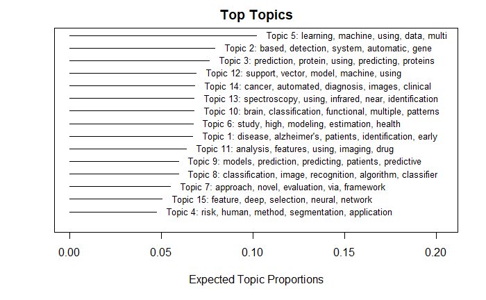

```r
plot(topic_model, n = 5, text.cex = 0.8)
```

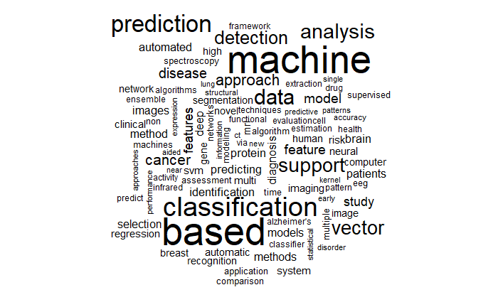

```r
topic_model %>% cloud()
```

- next we can “tidy” the model outputs usng the `tidy` function. This extracts the beta coefficients which represents the probabiklity of a given work being in a given topic. By extracting words (terms) with teh highet beta values, we can create a set of keyowrds for that topic and infer themes.

```r
tidy_tm <- tidy(topic_model)
tidy_tm
```

| topic | term | beta |
| --- | --- | --- |
| 1 |  | 9.799100e-261 |
| 2 |  | 3.374372e-170 |
| 3 |  | 6.448531e-230 |
| 4 |  | 3.906364e-04 |
| 5 |  | 3.305177e-137 |
| 6 |  | 1.045162e-203 |
| 7 |  | 1.620323e-173 |
| 8 |  | 7.705408e-177 |
| 9 |  | 2.163925e-199 |
| 10 |  | 3.181446e-216 |

[output cut: 990 more lines]

```r
NA
```

To clarify we can visualise the data to show terms with the highest probablity for each topic.

**Create a visualisation to show the top 10 terms in each of teh 15 topics. Label the topics to reflect the terms**

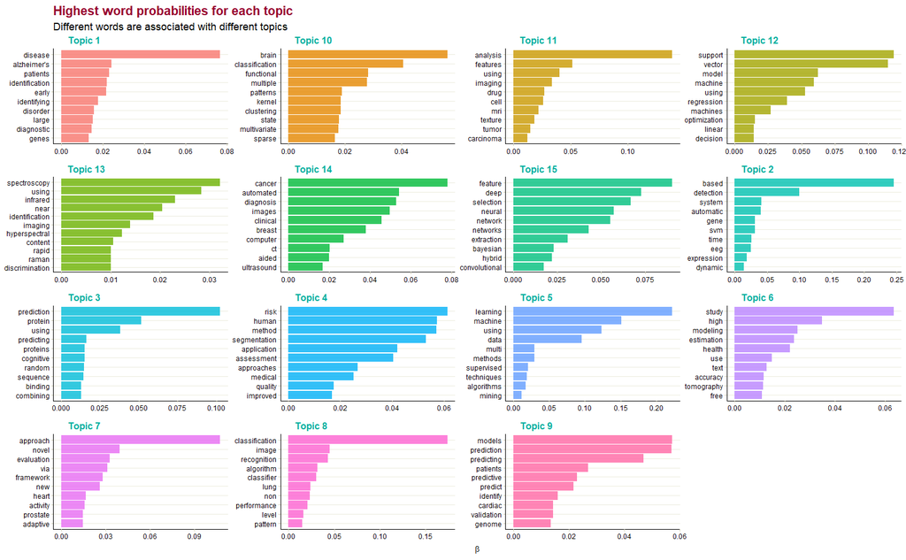

```r
tidy_tm %>%
    group_by(topic) %>%
    top_n(10, beta) %>%
    ungroup() %>%
    mutate(topic = paste0("Topic ", topic),
           term = reorder_within(term, beta, topic)) %>%
    ggplot(aes(term, beta, fill = as.factor(topic))) +
    geom_col(alpha = 0.8, show.legend = FALSE) +
    facet_wrap(~ topic, scales ="free") +
    coord_flip() +
    scale_x_reordered() +
    labs(x = NULL, y = expression(beta),
         title = "Highest word probabilities for each topic",
         subtitle = "Different words are associated with different topics") +
  phecharts::theme_phe() +
  ggsave("ml_ph_themes.png")
```

We can look at how these topics vary over time

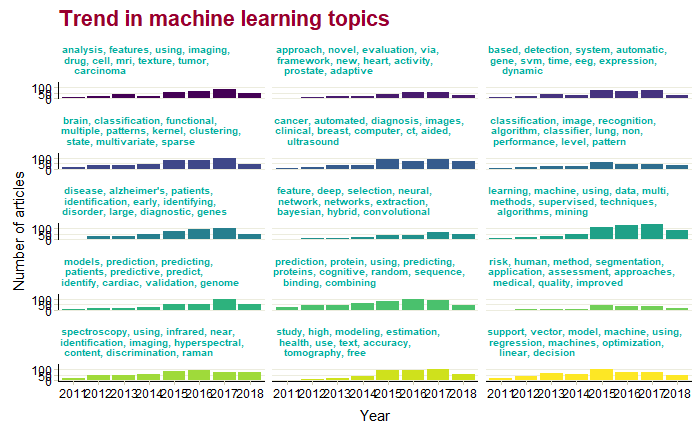

```r
td_gamma %>%
  select(-document) %>%
  dplyr::filter(year != 2019) %>%
  left_join(top_terms) %>%
  group_by(year) %>%
  count(kw) %>%
  ggplot(aes(year, n, fill = factor(kw))) +
  geom_col(show.legend = FALSE) +
  viridis::scale_fill_viridis(discrete = TRUE) +
  facet_wrap(~ kw, ncol = 3, labeller = label_wrap_gen(40)) +
  labs(title = "Trend in machine learning topics",
       y = "Number of articles", x = "Year") +
  phecharts::theme_phe() +
  theme(strip.text.x = element_text(size = rel(.6)))
```

Questions

- What are the downsides to topic modelling?
- How might you improve your results?

### Advanced

#### Relationship between topics

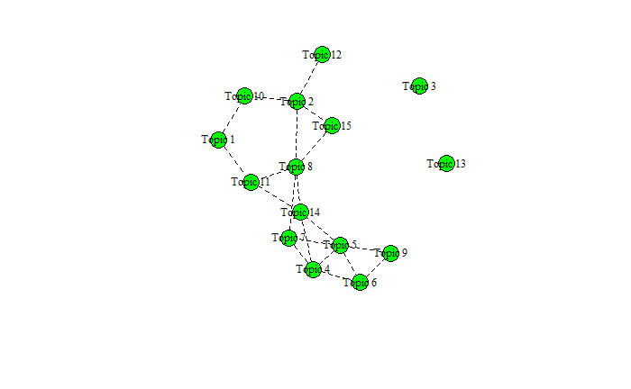

```r
topic_corr <- topicCorr(topic_model)
plot(topic_corr)
```

```r
NA
```

#### Online visualisations

```r
remotes::install_github("mroberts/stmBrowser",dependencies=TRUE)
install.packages("stminsights")
library(stmBrowser); library(stminsights)
run_stminsights()
```

```
Listening on http://127.0.0.1:7891
```

```r
stmCorrViz::stmCorrViz(prevfit, file = "test_1.html", documents_raw = check$abstract,  documents_matrix = data = meta, text = "abstract")
```

```r
stmCorrViz::stmCorrViz(mod = topic_model, file_out = "example.html", documents_raw = check$title, documents_matrix = big_dfm)


summary(topic_model)
```